What are the disc golf discs that Reddit recommends the most for beginners?

As a follow-up to my post about [Reddit’s most commonly recommended discs](https://discgolfdata.com/2020/12/31/The-most-recommended-discs-on-Reddit.html), I thought it would be handy to dive into posts specifically geared towards beginners. For this analysis, I largely followed the same steps detailed for the full post ([code available here](https://discgolfdata.com/pages/code_walkthroughs/redditdiscs.html)). This time, when collecting posts, the word “beginner” was also a search term.

So here they are…

## Reddit’s Top 20 most recommended beginner discs

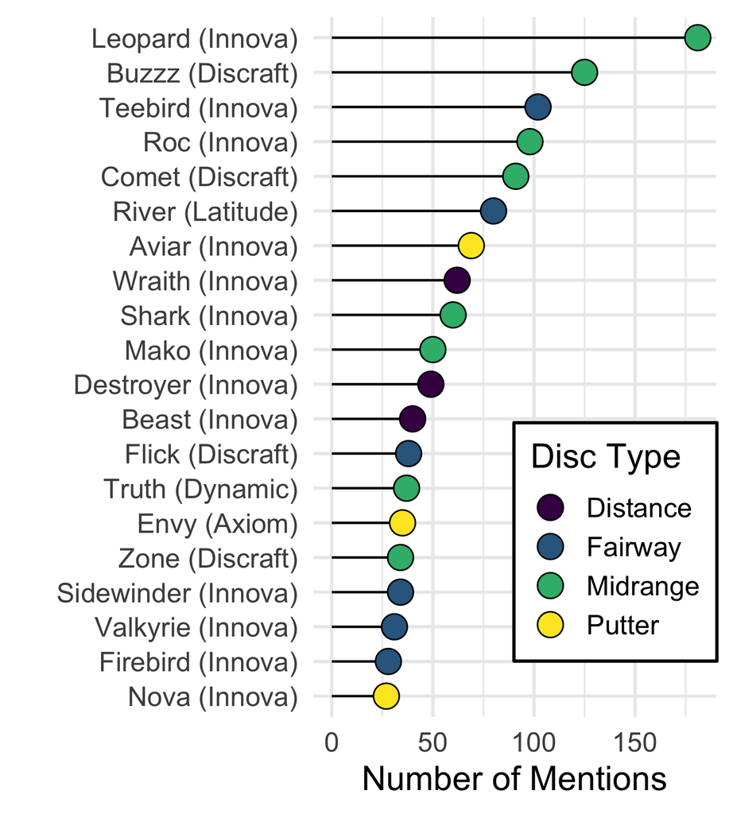

*Discs ranked by their number of mentions in recent r/discgolf comments about the “best beginner disc” or beginner disc “suggestions” or “recommendations”.*

I feel pretty good about this result - the [Leopard](https://amzn.to/3n4YIT4) is by far the most recommended beginner disc which is an excellent choice. Hence why Innova carries it in so many of their [disc sets](https://amzn.to/353V9q1)!

[Buzzz](https://amzn.to/3pJ8vQ6) is also another excellent suggestion. I throw a Big Z Buzzz and while it’s a great beginner disc, it’s also one you can mature into for really dead straight shots with a lot of power.

My guess is that discs like the Destroyer and Flick show up on the list for reasons related to the analysis rather than their suitability for new players. This web scraping will treat “You should absolutely NOT throw a Destroyer!” the same as a positive comment about one.

Here’s some more details about these discs and links for your convenience to purchase them!

| Manufacturer | Disc Mold | Speed | Glide | Turn | Fade |  |
| --- | --- | --- | --- | --- | --- | --- |
| Innova-Champion Discs | Leopard | 6 | 5 | -2 | 1 | [Buy It](https://amzn.to/3n4YIT4) |
| Discraft | Buzzz | 5 | 4 | -1 | 1 | [Buy It](https://amzn.to/3pJ8vQ6) |
| Innova-Champion Discs | Teebird | 7 | 5 | 0 | 2 | [Buy It](https://amzn.to/2KIPYox) |
| Innova-Champion Discs | Roc | 4 | 4 | 0 | 3 | [Buy It](https://amzn.to/38VsDYL) |
| Discraft | Comet | 4 | 5 | -2 | 1 | [Buy It](https://amzn.to/384wvaq) |
| Latitude 64 | River | 7 | 7 | -1 | 1 | [Buy It](https://amzn.to/3n7kkhm) |
| Innova-Champion Discs | Aviar | 2 | 3 | 0 | 1 | [Buy It](https://amzn.to/2JGJHcs) |
| Innova-Champion Discs | Wraith | 11 | 5 | -1 | 3 | [Buy It](https://amzn.to/2WYPLzR) |
| Innova-Champion Discs | Shark | 4 | 4 | 0 | 2 | [Buy It](https://amzn.to/3aXleuA) |
| Innova-Champion Discs | Mako | 4 | 5 | 0 | 0 | [Buy It](https://amzn.to/3mZiOxW) |
| Innova-Champion Discs | Destroyer | 12 | 5 | -1 | 3 | [Buy It](https://amzn.to/381KNZn) |
| Innova-Champion Discs | Beast | 10 | 5 | -2 | 2 | [Buy It](https://amzn.to/384YAyD) |
| Discraft | Flick | 9 | 4 | 1 | 4 | [Buy It](https://amzn.to/2JzCquM) |
| Dynamic Discs | Truth | 5 | 5 | 0 | 2 | [Buy It](https://amzn.to/382zcJE) |
| Dynamic Discs | Truth | 5 | 5 | -1 | 1 | Buy It |
| Axiom Discs | Envy | 3 | 3 | 0 | 2 | [Buy It](https://amzn.to/353hrbj) |
| Innova-Champion Discs | Sidewinder | 9 | 5 | -3 | 1 | [Buy It](https://amzn.to/38PbL5X) |
| Discraft | Zone | 4 | 3 | 0 | 3 | [Buy It](https://amzn.to/3o5X6cJ) |
| Innova-Champion Discs | Valkyrie | 9 | 4 | -2 | 2 | [Buy It](https://amzn.to/38WgvXz) |
| Innova-Champion Discs | Firebird | 9 | 3 | 0 | 4 | [Buy It](https://amzn.to/3aZYhqD) |
| Innova-Champion Discs | Nova | 2 | 3 | 0 | 0 | [Buy It](https://amzn.to/2KKeBBj) |